# explore.taxonomy.Leray

M Fisher

1/26/2021

# Description

Explorative plots looking at taxonomic assignments from **Leray** sequences.

# Set up

This script requires the following packages:

```r
library(here)
library(tidyverse)
library(magrittr)
library(cowplot)
```

User directories

```r
indir_blast  <- 'test-lane-1/data/blast'
indir_asv    <- 'test-lane-1/data/dada2/Leray'
indir_meta   <- 'test-lane-1/data/cutadapt/Leray'
outdir       <- 'test-lane-1/results'
```

Which marker is being analyzed?

```r
marker <- 'Leray'
```

What are the names of the processed blast file with taxonomy from script 6?

```r
# hashes with unique staxids
infile1 <- 'lane1_leray_blast_uniqueIDs_taxonomy.csv'

# hashes with multiple IDs, that required the LCA function
infile2 <- 'lane1_leray_blast_multipleIDs_taxonomy.csv'
```

# Data

Taxonomy from script `6.parse.blast.results`

```r
tax_key <- read_csv(here(indir_blast, infile2)) %>%
  rename("Hash"=representative)
tax_key %<>% bind_rows(read_csv(here(indir_blast, infile1)) %>%
              rename("Hash"=qseqid) %>%
                mutate(taxID="unique", score="unique") %>%
              dplyr::select(all_of(colnames(tax_key))))
```

Sequencing sample metadata, so that we can connect sample name (actually a number; in the ASV table) to sample ID.

```r
metadat <- read_csv(here(indir_meta, paste0('cutadapt_output_metadata_',marker,'.csv')))
metadat %<>% dplyr::select(Sample_name, file1) %>%
  mutate(SampleID=str_remove(file1,"_L001_R1_001.fastq.fastq")) %>%
  mutate(SampleID=str_remove(SampleID,paste0("Locus_",marker,"_",marker,"_"))) %>%
  mutate(SampleID=ifelse(as.numeric(Sample_name) > 10, str_sub(SampleID,start=1, end=-5),
                         str_sub(SampleID,start=1, end=-4))) %>%
  mutate(Group=ifelse(SampleID %in% c("Kangaroo","PCRNegative","SpeedVacNegative"), "Control", str_sub(SampleID, start=1,end=4))) %>%
  mutate(Group=ifelse(Group!="WASS",Group,ifelse(grepl("2020",SampleID),"WASS 2020", "WASS 2018"))) %>%
  dplyr::select(-file1)
```

### merged

ASV table

```r
mdat <- read_csv(here(indir_asv, 'merged_ASV_table.csv')) %>%
  mutate(dataset="merged")
```

Join the sample metadata to the ASV dataframe

```r
mdat %<>% left_join(metadat,by="Sample_name")
```

Join the taxonomic key to the ASV dataframe

```r
mdat %<>% left_join(filter(tax_key, dataset=="merged"),by=c("Hash","dataset"))
```

### forward

ASV table

```r
fdat <- read_csv(here(indir_asv, 'F_ASV_table.csv')) %>%
  mutate(dataset="forward")
```

Join the sample metadata to the ASV dataframe

```r
fdat %<>% left_join(metadat,by="Sample_name")
```

Join the taxonomic key to the ASV dataframe

```r
fdat %<>% left_join(filter(tax_key, dataset=="forward"),by=c("Hash","dataset"))
```

### reverse

ASV table

```r
rdat <- read_csv(here(indir_asv, 'R_ASV_table.csv')) %>%
  mutate(dataset="reverse")
```

Join the sample metadata to the ASV dataframe

```r
rdat %<>% left_join(metadat,by="Sample_name")
```

Join the taxonomic key to the ASV dataframe

```r
rdat %<>% left_join(filter(tax_key, dataset=="reverse"),by=c("Hash","dataset"))
```

### combine & quality check

```r
dat <- bind_rows(mdat,rdat,fdat)
```

**1.** Make sure that each hash has only one set of taxonomic information

```r
checkdat <- dat %>%
  group_by(Sample_name,Hash,dataset) %>%
  summarise(count=n(), .groups="drop") %>%
  filter(count > 1)
checkdat
```

```
## # A tibble: 16 x 4
##    Sample_name Hash                                     dataset count
##          <dbl> <chr>                                    <chr>   <int>
##  1           1 36f2085e54fa4d7359a9ae1008d937062e908f76 merged      2
##  2           1 63494c54dc2c7db0801fbe6686f453a5c58a6050 forward     2
##  3           2 5d3190f1c0344c9e76473571133c484478e4da94 merged      2
##  4           2 63494c54dc2c7db0801fbe6686f453a5c58a6050 forward     2
##  5           2 ced9f4c6ecc3506ff8ae1704b3c03311ad561b75 merged      2
##  6           5 00c4cd9eb6681c886c9c7a6188af57a17200d851 forward     2
##  7           5 69032d10686b8903ec61760d07ee708e58bac03b forward     2
##  8           5 d80fb708ae689e3b67fc01186b3f0b48e93f5284 merged      2
##  9           6 00c4cd9eb6681c886c9c7a6188af57a17200d851 forward     2
## 10           6 d80fb708ae689e3b67fc01186b3f0b48e93f5284 merged      2
## 11           7 425b519aaf48b4b04fd973d5fce3097bbbba89d2 reverse     2
## 12           7 4f8c299ae11dc681a819a0fa3d92c1e48e909ff5 merged      2
## 13          65 3e70c000f1a73e7915e91d0ff81942c2efc40668 forward     2
## 14          65 83634ac0f80d249abf69cf037bf22cbd2694c4d9 merged      2
## 15          66 29b117bedce8d9d832e34e6afd5ed8220146ee98 forward     2
## 16          99 914a9dce75fcda80bb1b209e0d5af303dff08ed7 forward     2
```

It looks like all of those with a ‘2’ count either are true duplicates (?) or have matching taxonomy between the two unique IDs, but one row of taxonomic info is more fine-scale than the other. Save only the most specific taxonomic info.

```r
## rows to remove have the most NAs
checkdat %<>% left_join(dat,by=c("Sample_name","Hash","dataset")) %>%
  arrange(desc(rowSums(is.na(.)))) %>%
  distinct(Sample_name,dataset, .keep_all = TRUE)

## remove those rows
dat %<>% anti_join(checkdat, by=c("Sample_name","Hash", "dataset","rank", "taxon"))

rm(checkdat)
```

```r
dat %>%
  group_by(Sample_name,Hash,dataset) %>%
  summarise(count=n(), .groups="drop") %>%
  filter(count > 1)
```

```
## # A tibble: 2 x 4
##   Sample_name Hash                                     dataset count
##         <dbl> <chr>                                    <chr>   <int>
## 1           2 ced9f4c6ecc3506ff8ae1704b3c03311ad561b75 merged      2
## 2           5 00c4cd9eb6681c886c9c7a6188af57a17200d851 forward     2
```

These are true duplicates - I’m not sure why they weren’t filtered out.

```r
checkdat <- dat %>%
  group_by(Sample_name,Hash,dataset) %>%
  summarise(count=n(), .groups="drop") %>%
  filter(count > 1) %>% left_join(dat,by=c("Sample_name","Hash","dataset"))

checkdat %<>% slice(2,4)

## remove those rows
dat %<>% anti_join(checkdat, by=c("Sample_name","Hash", "dataset","rank", "taxon"))

rm(checkdat)

dat %>%
  group_by(Sample_name,Hash,dataset) %>%
  summarise(count=n(), .groups="drop") %>%
  filter(count > 1)
```

```
## # A tibble: 0 x 4
## # ... with 4 variables: Sample_name <dbl>, Hash <chr>, dataset <chr>,
## #   count <int>
```

**2.** Find the number of hashes with missing taxonomic information

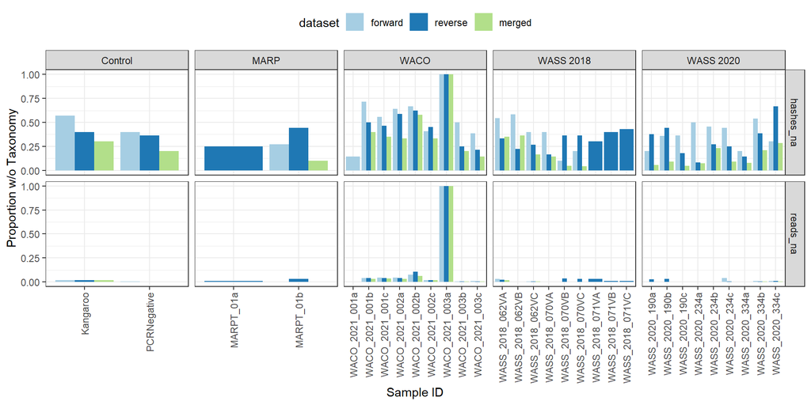

The proportion of reads without taxonomic assigments is crazy low. Except for WACO_2021_003a, which looks like it will have no data.

# Ratios

A quick look at the proportion of reads belonging to each taxa, for every sample.

```r
# don't want NAs showing up in the plots
dat2 <- filter(dat, !is.na(rank))
```

## Controls

What DNA did we pick up in the controls?

```r
control_dat <- dat2 %>% filter(Group=="Control")
```

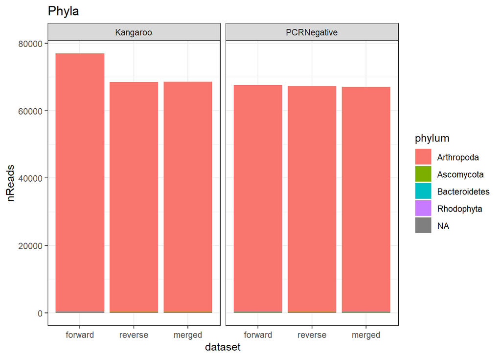

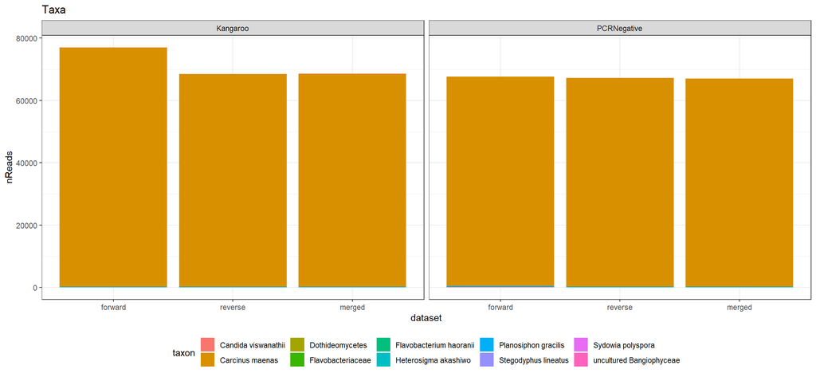

It looks like the green crab DNA once again got…everywhere. The rest is mostly bacteria and fungus (whereas BF3 had only bacteria). The weirdest thing is that there isn’t any kangaroo DNA in the positive control??

Non-bacterial species in the negative control:

1. *Planosiphon gracilis*, a brown algae
2. *Heterosigma akashiwo*, a unicellular red algae
3. *Stegodyphus*, a spider
4. *Sydowia polyspora*, a plant pathogen that infects Douglas firs
5. *Bangiophyceae* (class; phylum=Rhodophyta), a red algae
6. *Dothideomycetes*, a fungus
7. *Candida viswanathii*, a yeast

Get a list of taxa from the negative controls, to remove from the samples:

```r
taxa_to_remove <- control_dat %>%
  filter(!(taxon %in% c("Carcinus maenas","Carcinus aestuarii"))) %>%
  pull(taxon)
```

## Predator v Prey

How much predator DNA did we pick up, from each sample?

First, get total reads per sample so that we can calculate proportion of reads per taxon.

```r
total_reads_per_sample <- dat2 %>%
  group_by(Group,SampleID,dataset) %>%
  summarise(total_reads=sum(nReads), .groups="drop")
```

### Green Crab

```r
egc_dat <- dat2 %>%
  filter(Group %in% c("WACO","WASS 2020", "WASS 2018")) %>%
  # remove all taxa in the negative controls, except green crab
  filter(!(taxon %in% taxa_to_remove))

egc_pred <- egc_dat %>%
  mutate(Predator=ifelse(taxon == "Carcinus maenas" | taxon == "Carcinus aestuarii",1,0)) %>%
  group_by(Group,SampleID,dataset,Predator) %>%
  summarise(sumReads=sum(nReads)) %>%
  left_join(total_reads_per_sample,by=c("Group","SampleID","dataset")) %>%
  mutate(pReads=sumReads/total_reads)
```

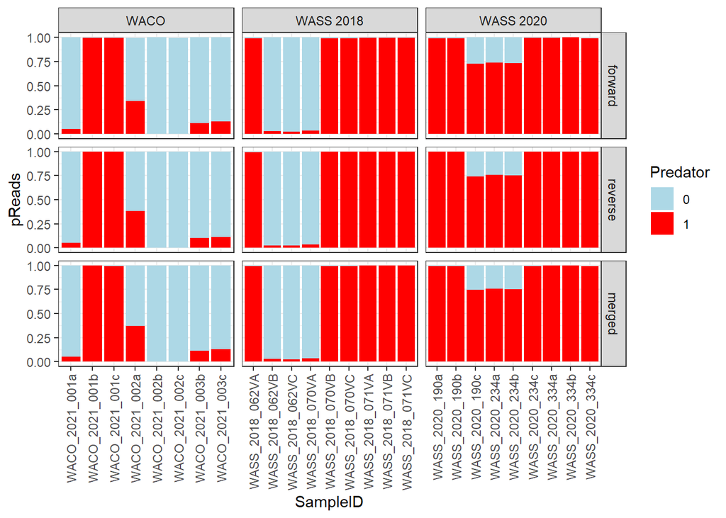

### Dungies

```r
dungy_dat <- dat2 %>%
  filter(Group=="MARP") %>%
  filter(!(taxon %in% taxa_to_remove))

dungy_pred <- dungy_dat %>%
  mutate(Predator=ifelse(taxon == "Metacarcinus magister",1,0)) %>%
  group_by(Group,SampleID,dataset,Predator) %>%
  summarise(sumReads=sum(nReads)) %>%
  left_join(total_reads_per_sample,by=c("Group","SampleID","dataset")) %>%
  mutate(pReads=sumReads/total_reads)
```

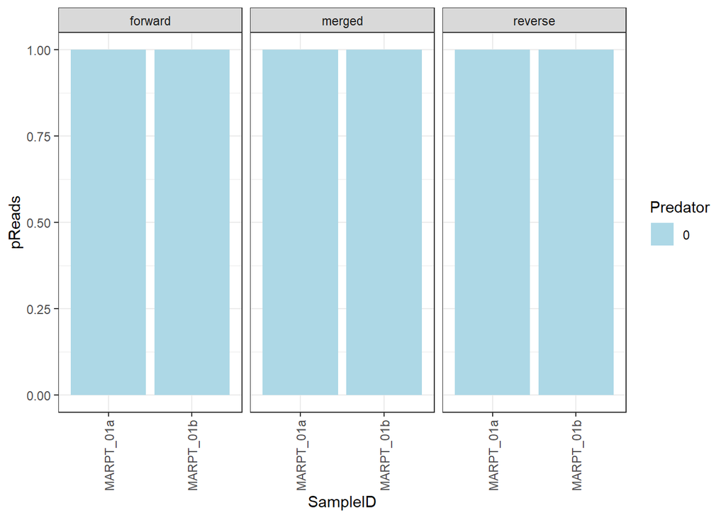

## Diet Composition

### Green Crab

Remove predator DNA, and bacteria that weren’t captured in the negative controls. then recalculate total reads.

```r
egc_prey <- egc_dat %>%
  mutate(Predator=ifelse(taxon == "Carcinus maenas" | taxon == "Carcinus aestuarii",1,0)) %>%
  filter(Predator==0) %>%
  filter(!(phylum %in% c("Actinobacteria","Bacteroidetes","Planctomycetes","Proteobacteria")))


egc_prey_total_reads <- egc_prey %>%
  group_by(Group,SampleID,dataset) %>%
  summarise(total_reads=sum(nReads))
```

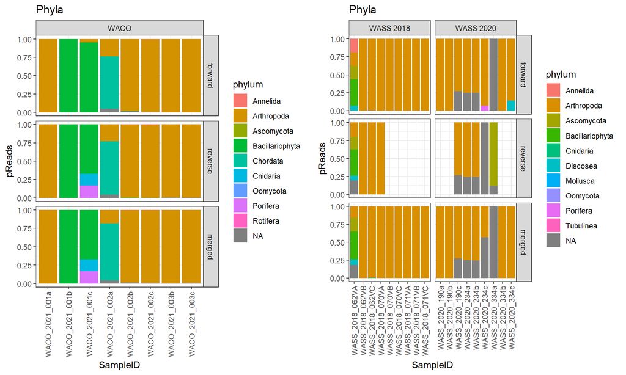

I suspect the *Chordata* is contamination from me or from the SEFS lab…

```
## # A tibble: 5 x 2
##   SampleID       taxon
##   <chr>          <chr>
## 1 WACO_2021_002a Mammalia
## 2 WACO_2021_002a Chordata
## 3 WACO_2021_002a Macropodidae
## 4 WACO_2021_002c Homo sapiens
## 5 WACO_2021_002a Macropus
```

Weird, it almost looks like WACO_2021_002a should be the positive control???

Let’s remove the *Chordata* DNA for now.

```r
egc_prey %<>% filter(phylum!="Chordata")

egc_prey_total_reads <- egc_prey %>%
  group_by(Group,SampleID,dataset) %>%
  summarise(total_reads=sum(nReads))
```

Ok, with the new prey data set:

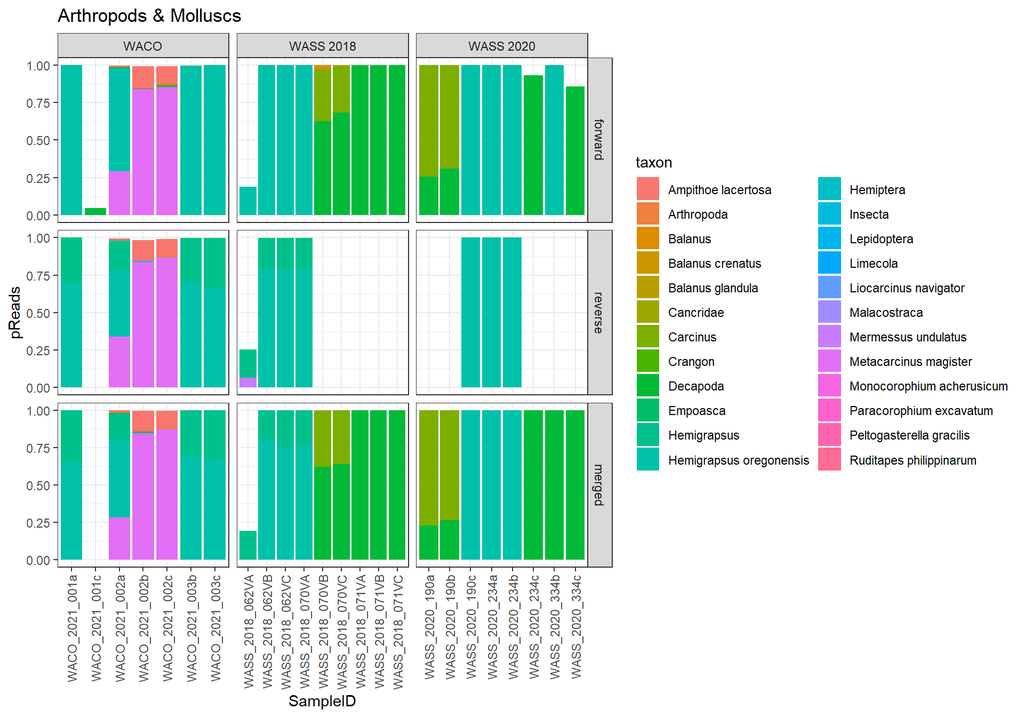

Similar to BF3, we have lots of Dungeness crab and *Hemigrapsus* reads (plus crab that couldn’t be ID’d to genus or species, *Malacostraca*, *Cancridae*, *Carcinus*, *Liocarcinus*). And some things must be contamination, or non-specific primer matches from having such short sequences (Lepidoptera, Mermessus spp, Empoasca). But there are also some other cool things:

- amphipods: *Ampithoe lacertosa* (also picked up in BF3)
- shrimp: *Crangon* (not in BF3)
- barnacles (*Balanus*)
- bivalves (*Ruditapes philippinarum*) -yay!!!

Weird thing about the bivalve results between Leray and BF3 – same species, but different crabs??

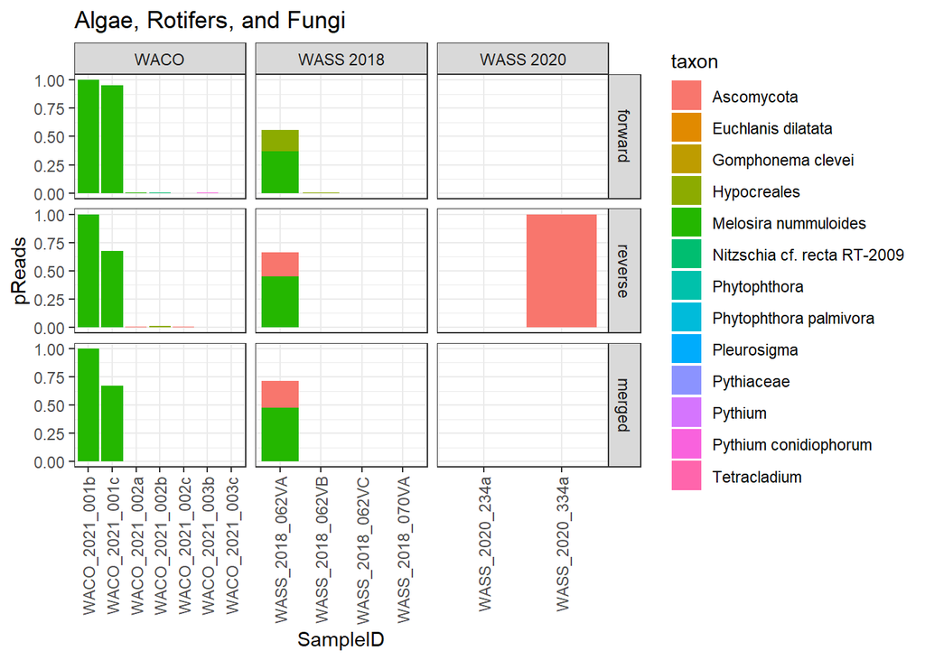

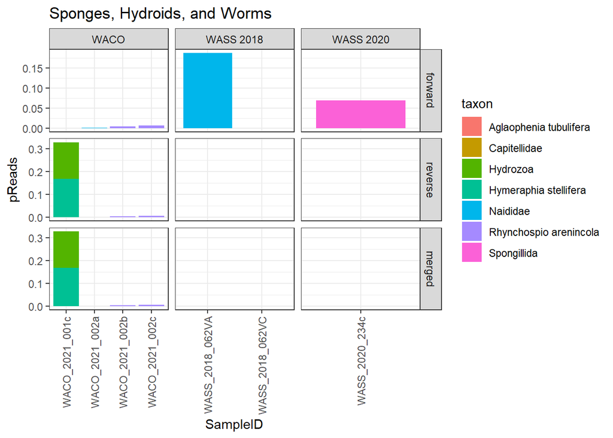

Summarise and save the prey data

```r
egc_prey_summary <- egc_prey %>%
  separate(col=SampleID, into=c("Crab","replicate"), sep=-1,remove=FALSE) %>%
  left_join(egc_prey_total_reads,by=c("Group","SampleID","dataset")) %>%
  mutate(pReads=nReads/total_reads) %>%
  group_by(taxon,kingdom,phylum,class,order,family,genus,species,dataset,score) %>%
  summarise(nCrabs=length(unique(Crab)), nReplicates=length(unique(SampleID)), total_reads=sum(nReads), mean_pReads=mean(pReads), sd_pReads=sd(pReads),
            SampleIDs=paste0(SampleID,collapse=","))


write.csv(egc_prey_summary, here(outdir,"Leray_BLAST_prey_taxa_EGC.csv"), row.names=FALSE)
```

## Dungies

```r
dungy_prey <- dungy_dat %>%
  mutate(Predator=ifelse(taxon == "Metacarcinus magister",1,0)) %>%
  filter(Predator==0) %>%
  filter(!(phylum %in% c("Actinobacteria","Bacteroidetes","Planctomycetes","Proteobacteria")))

dungy_prey_total_reads <- dungy_prey %>%
  group_by(SampleID,dataset) %>%
  summarise(total_reads=sum(nReads))
```

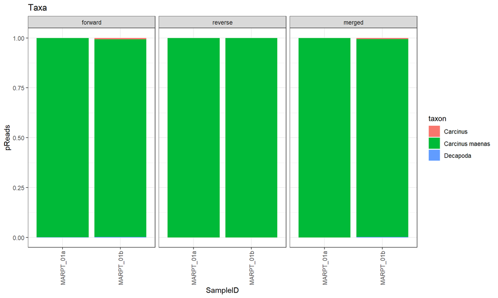

Summarise and save the prey data

```r
dungy_prey_summary <- dungy_prey %>%
  separate(col=SampleID, into=c("Crab","replicate"), sep=-1,remove=FALSE) %>%
  left_join(dungy_prey_total_reads,by=c("SampleID","dataset")) %>%
  mutate(pReads=nReads/total_reads) %>%
  group_by(taxon,kingdom,phylum,class,order,family,genus,species,dataset,score) %>%
  summarise(nCrabs=length(unique(Crab)), nReplicates=length(unique(SampleID)), total_reads=sum(nReads), mean_pReads=mean(pReads), sd_pReads=sd(pReads),
            SampleIDs=paste0(SampleID,collapse=","))


write.csv(dungy_prey_summary, here(outdir,"Leray_BLAST_prey_taxa_Dungeness.csv"), row.names=FALSE)
```